# warmup03-yvonne-zhou

Yvonne Zhou

2/15/2019

# Importing Data

> Do the data have a header containing the variable names? Answer: Yes. There is a header containing the variable names.

> Are the values for an observation separated by a comma, blank, or tab? Answer: Yes, the values for an observation are separated by a comma.

> Are there any missing values? If so, how are they codified? Answer: Yes, there are missing values, and they are codified as “”.

```r
head(read.table("https://raw.githubusercontent.com/ucb-stat133/stat133-hws/master/data/nba2018-players.csv", sep = ",", col.names = c("player","team","position","height","weight","age","experience","college","salary","games","minutes","points","points3","points2","points1"), skip = 1))
```

```
##              player team position height weight age experience
## 1        Al Horford  BOS        C     82    245  30          9
## 2      Amir Johnson  BOS       PF     81    240  29         11
## 3     Avery Bradley  BOS       SG     74    180  26          6
## 4 Demetrius Jackson  BOS       PG     73    201  22          0
## 5      Gerald Green  BOS       SF     79    205  31          9
## 6     Isaiah Thomas  BOS       PG     69    185  27          5
##                         college   salary games minutes points points3
## 1         University of Florida 26540100    68    2193    952      86
## 2                               12000000    80    1608    520      27
## 3 University of Texas at Austin  8269663    55    1835    894     108
## 4      University of Notre Dame  1450000     5      17     10       1
## 5                                1410598    47     538    262      39
## 6      University of Washington  6587132    76    2569   2199     245
##   points2 points1
## 1     293     108
## 2     186      67
## 3     251      68
## 4       2       3
## 5      56      33
## 6     437     590
```

```r
head(read.csv("https://raw.githubusercontent.com/ucb-stat133/stat133-hws/master/data/nba2018-players.csv", sep = ","))
```

```
##              player team position height weight age experience
## 1        Al Horford  BOS        C     82    245  30          9
## 2      Amir Johnson  BOS       PF     81    240  29         11
## 3     Avery Bradley  BOS       SG     74    180  26          6
## 4 Demetrius Jackson  BOS       PG     73    201  22          0
## 5      Gerald Green  BOS       SF     79    205  31          9
## 6     Isaiah Thomas  BOS       PG     69    185  27          5
##                         college   salary games minutes points points3
## 1         University of Florida 26540100    68    2193    952      86
## 2                               12000000    80    1608    520      27
## 3 University of Texas at Austin  8269663    55    1835    894     108
## 4      University of Notre Dame  1450000     5      17     10       1
## 5                                1410598    47     538    262      39
## 6      University of Washington  6587132    76    2569   2199     245
##   points2 points1
## 1     293     108
## 2     186      67
## 3     251      68
## 4       2       3
## 5      56      33
## 6     437     590
```

```r
# assembling url so it fits on the screen
github <- 'https://raw.githubusercontent.com/ucb-stat133/stat133-hws/'
repo <- 'master/data/nba2018-players.csv'
datafile <- paste0(github, repo)
head(read.table(datafile, sep = ",", col.names = c("player","team","position","height","weight","age","experience","college","salary","games","minutes","points","points3","points2","points1"), skip = 1))
```

```
##              player team position height weight age experience
## 1        Al Horford  BOS        C     82    245  30          9
## 2      Amir Johnson  BOS       PF     81    240  29         11
## 3     Avery Bradley  BOS       SG     74    180  26          6
## 4 Demetrius Jackson  BOS       PG     73    201  22          0
## 5      Gerald Green  BOS       SF     79    205  31          9
## 6     Isaiah Thomas  BOS       PG     69    185  27          5
##                         college   salary games minutes points points3
## 1         University of Florida 26540100    68    2193    952      86
## 2                               12000000    80    1608    520      27
## 3 University of Texas at Austin  8269663    55    1835    894     108
## 4      University of Notre Dame  1450000     5      17     10       1
## 5                                1410598    47     538    262      39
## 6      University of Washington  6587132    76    2569   2199     245
##   points2 points1
## 1     293     108
## 2     186      67
## 3     251      68
## 4       2       3
## 5      56      33
## 6     437     590
```

```r
head(read.csv(datafile, sep = ","))
```

```
##              player team position height weight age experience
## 1        Al Horford  BOS        C     82    245  30          9
## 2      Amir Johnson  BOS       PF     81    240  29         11
## 3     Avery Bradley  BOS       SG     74    180  26          6
## 4 Demetrius Jackson  BOS       PG     73    201  22          0
## 5      Gerald Green  BOS       SF     79    205  31          9
## 6     Isaiah Thomas  BOS       PG     69    185  27          5
##                         college   salary games minutes points points3
## 1         University of Florida 26540100    68    2193    952      86
## 2                               12000000    80    1608    520      27
## 3 University of Texas at Austin  8269663    55    1835    894     108
## 4      University of Notre Dame  1450000     5      17     10       1
## 5                                1410598    47     538    262      39
## 6      University of Washington  6587132    76    2569   2199     245
##   points2 points1
## 1     293     108
## 2     186      67
## 3     251      68
## 4       2       3
## 5      56      33
## 6     437     590
```

```r
data_types <- c("character", "factor", "factor", "integer", "integer", "integer", "integer", "character", "double", "integer", "integer", "integer", "integer", "integer", "integer")
```

```r
nba <- read.csv(datafile, sep = ",", colClasses = data_types)
str(nba, vec.len = 1)
```

```
## 'data.frame':    477 obs. of  15 variables:
##  $ player    : chr  "Al Horford" ...
##  $ team      : Factor w/ 30 levels "ATL","BOS","BRK",..: 2 2 ...
##  $ position  : Factor w/ 5 levels "C","PF","PG",..: 1 2 ...
##  $ height    : int  82 81 ...
##  $ weight    : int  245 240 ...
##  $ age       : int  30 29 ...
##  $ experience: int  9 11 ...
##  $ college   : chr  "University of Florida" ...
##  $ salary    : num  26540100 ...
##  $ games     : int  68 80 ...
##  $ minutes   : int  2193 1608 ...
##  $ points    : int  952 520 ...
##  $ points3   : int  86 27 ...
##  $ points2   : int  293 186 ...
##  $ points1   : int  108 67 ...
```

```r
nba2 <- read.table(datafile, sep = ",", col.names = c("player","team","position","height","weight","age","experience","college","salary","games","minutes","points","points3","points2","points1"), colClasses = data_types, skip = 1)
str(nba2, vec.len = 1)
```

```
## 'data.frame':    477 obs. of  15 variables:
##  $ player    : chr  "Al Horford" ...
##  $ team      : Factor w/ 30 levels "ATL","BOS","BRK",..: 2 2 ...
##  $ position  : Factor w/ 5 levels "C","PF","PG",..: 1 2 ...
##  $ height    : int  82 81 ...
##  $ weight    : int  245 240 ...
##  $ age       : int  30 29 ...
##  $ experience: int  9 11 ...
##  $ college   : chr  "University of Florida" ...
##  $ salary    : num  26540100 ...
##  $ games     : int  68 80 ...
##  $ minutes   : int  2193 1608 ...
##  $ points    : int  952 520 ...
##  $ points3   : int  86 27 ...
##  $ points2   : int  293 186 ...
##  $ points1   : int  108 67 ...
```

```r
identical(nba, nba2)
```

```
## [1] TRUE
```

# Technical Questions about importing data

> What happens to the column names of the imported data when you invoke read.csv(datafile, header = FALSE, nrows = 10)? Answer: The column names of the imported data would be processed as a row.

> What happens to the data types of the columns when you invoke read.csv(datafile, header = FALSE, nrows = 10)? Answer: The data types of the columns would all be set to be factors.

> Why does the command read.table(datafile, nrows = 10) fall to import the data? Answer: The character delimiter is not passed in the function.

> Say you import nba2018-players.csv in two different ways. In the first option you import the data without specifying the data type of each column. In the second option you do specify the data types as in data_types. You may wonder whether both options return a data frame of the same memory size. You can actually use the function object.size() that provides an estimate of the memory that is being used to store an R object. What data importing function returns the smallest data frame (in terms of memory size)? Answer: The second data importing function returns the smallest data frame in term of memory size. This is because when importing the function has one parameter to deal with.

> Say the object nba is the data frame produced when importing nba2018-players.csv. If you invoke as.matrix(nba), what happens to the data values of this matrix? Answer: The values of the matrix are transformed into character.

# Examine Salary

```r
summary(nba$salary)
```

```
##     Min.  1st Qu.   Median     Mean  3rd Qu.     Max.
##     5145  1050961  3000000  5804697  8269663 30963450
```

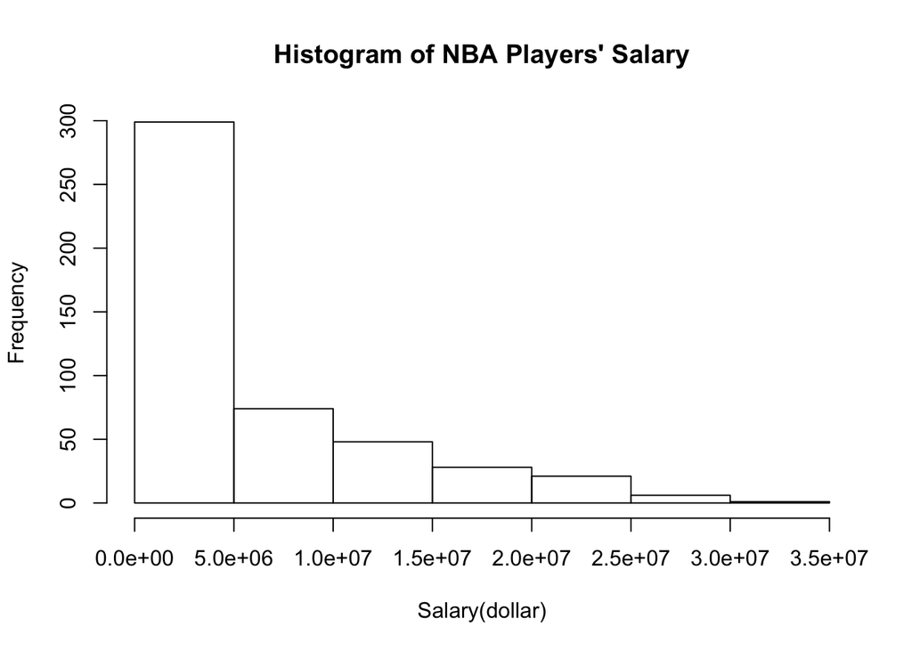

```r
hist(nba$salary, main = "Histogram of NBA Players' Salary", xlab = "Salary(dollar)")
```

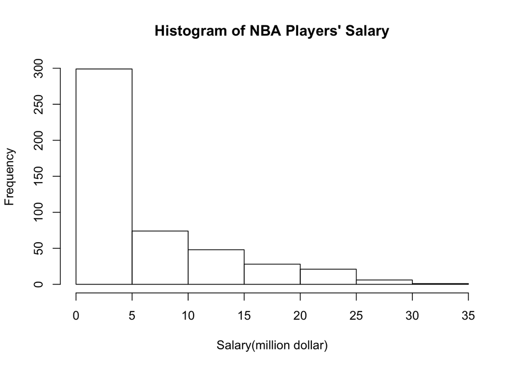

```r
nba$salary2 <- nba$salary / 1000000
hist(nba$salary2, main = "Histogram of NBA Players' Salary", xlab = "Salary(million dollar)")
```

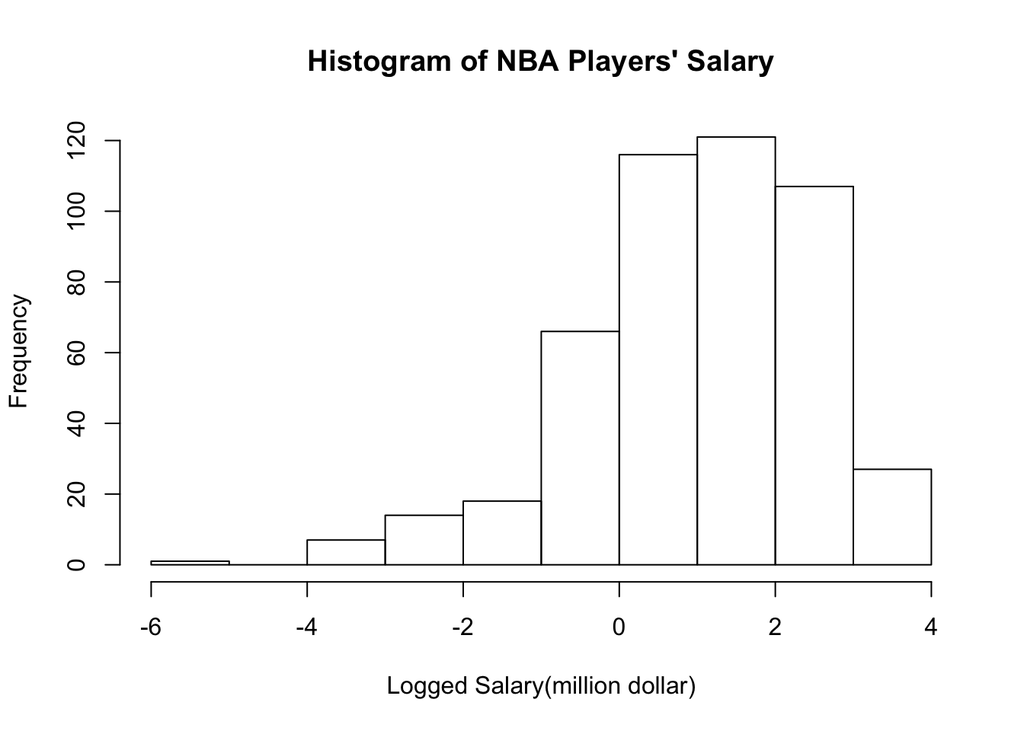

```r
hist(log(nba$salary2), main = "Histogram of NBA Players' Salary", xlab = "Logged Salary(million dollar)")
```

```r
#The log transformation make the salary2 distribution more symmetric. The rest of the distribution are high comparing to the small values on the left. This histogram is not symmetric, skewed left, and it is not uniform.
```

```r
low <- c(log(nba$salary2) < -3)
length(which(low))
```

```
## [1] 8
```

```r
nba$lsalary <- low
nbadf <- nba[nba$lsalary == TRUE, c("player", "weight", "height", "team", "position")]
nbadf
```

```
##                  player weight height team position
## 18        Dahntay Jones    225     78  CLE       SF
## 21          Edy Tavares    260     87  CLE        C
## 82          Gary Payton    190     75  MIL       PG
## 204 Marcus Georges-Hunt    216     77  ORL       SG
## 207     Patricio Garino    210     78  ORL       SG
## 210      Alex Poythress    238     79  PHI       PF
## 400          Ben Bentil    235     81  DAL       PF
## 467      Elijah Millsap    225     78  PHO       SG
```

```r
nba <- nba[nba$lsalary == FALSE, ]
dim(nba)
```

```
## [1] 469  17
```

# Explore Points

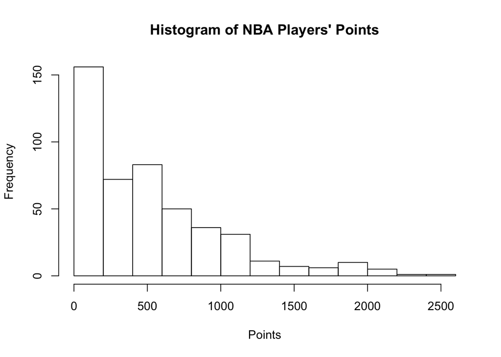

```r
hist(nba$points, main = "Histogram of NBA Players' Points", xlab = "Points")
```

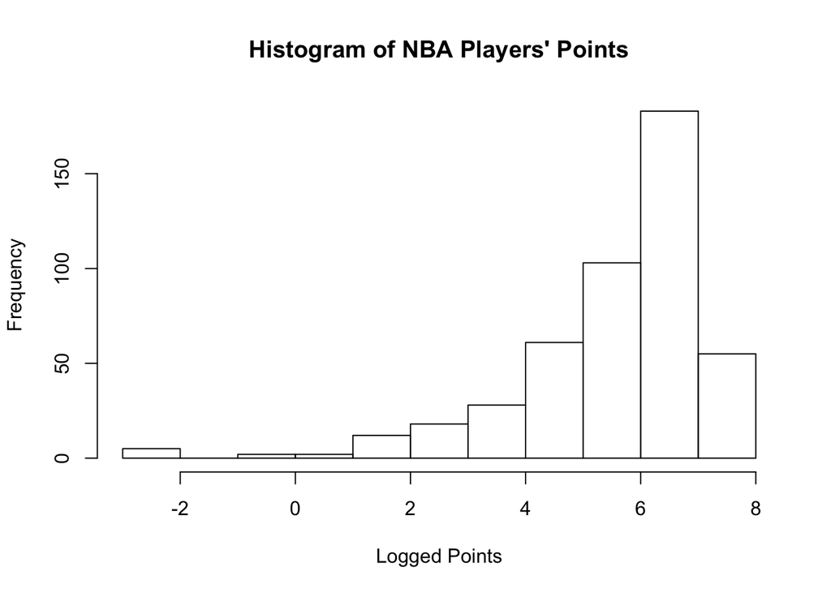

```r
nba$points[nba$points == 0] <- 0.1
hist(log(nba$points), main = "Histogram of NBA Players' Points", xlab = "Logged Points")
```

```r
#The log transformation make the points distribution more symmetric. This histogram is not symmetric, skewed left, and it is not uniform. The histogram shows that more players have higher logged points.
```

# Transforming Age into a Factor

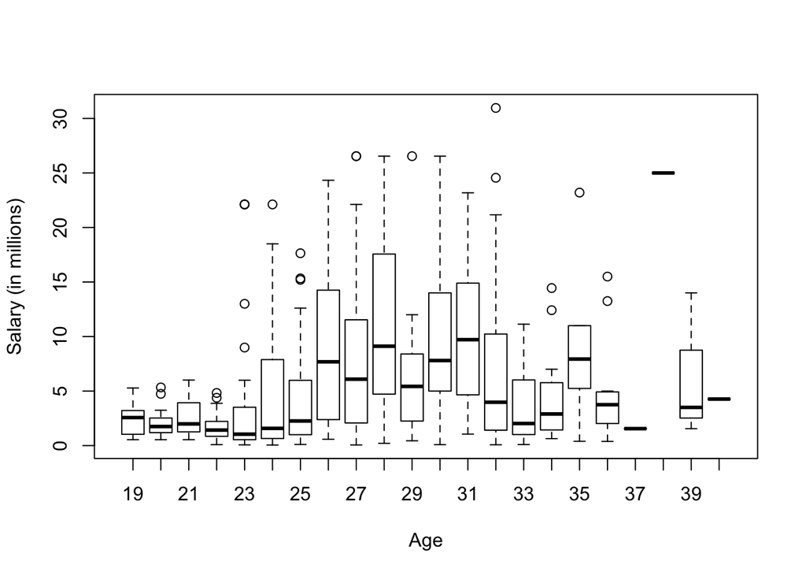

```r
boxplot(salary2 ~ age, data = nba,
xlab = "Age", ylab = "Salary (in millions)")
```

```r
#There seems to be a difference in salaries depending on the age of the players.
```

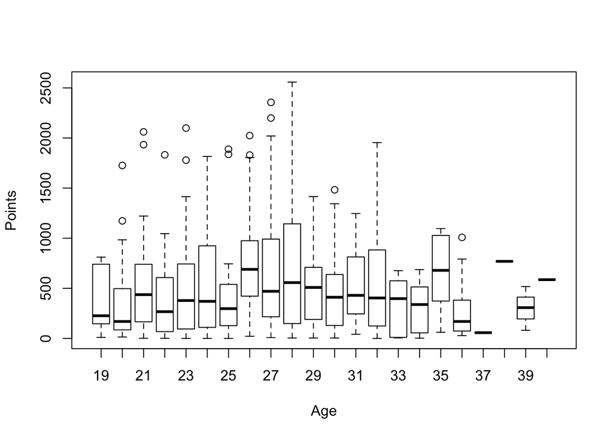

```r
boxplot(points ~ age, data = nba,
xlab = "Age", ylab = "Points")
```

```r
#There does not seems to be a large difference in points depending on the age of the players.
```

```r
age2 <- c(nba$age)
age2 <- replace(age2, age2 < 20, 20)
age2 <- cut(age2, breaks = c(19, 25, 30, Inf), labels = c("20-24", "25-29", "30+"))
age2
```

```
##   [1] 25-29 25-29 25-29 20-24 30+   25-29 25-29 20-24 20-24 25-29 20-24
##  [12] 20-24 20-24 20-24 25-29 30+   30+   30+   20-24 25-29 30+   30+
##  [23] 20-24 20-24 25-29 30+   20-24 25-29 30+   30+   20-24 20-24 20-24
##  [34] 20-24 25-29 25-29 20-24 20-24 20-24 25-29 20-24 20-24 30+   20-24
##  [45] 25-29 25-29 25-29 20-24 25-29 20-24 20-24 20-24 25-29 25-29 25-29
##  [56] 20-24 30+   25-29 20-24 20-24 20-24 20-24 20-24 30+   25-29 30+
##  [67] 30+   25-29 30+   20-24 25-29 30+   20-24 30+   20-24 20-24 30+
##  [78] 20-24 20-24 20-24 25-29 20-24 30+   25-29 20-24 20-24 25-29 25-29
##  [89] 25-29 30+   20-24 25-29 30+   20-24 20-24 20-24 30+   30+   25-29
## [100] 20-24 20-24 25-29 20-24 25-29 25-29 25-29 30+   20-24 25-29 20-24
## [111] 25-29 25-29 30+   20-24 20-24 20-24 20-24 30+   20-24 20-24 25-29
## [122] 20-24 20-24 20-24 20-24 20-24 25-29 25-29 20-24 25-29 25-29 25-29
## [133] 25-29 20-24 20-24 25-29 20-24 20-24 20-24 30+   25-29 25-29 20-24
## [144] 25-29 30+   25-29 20-24 20-24 25-29 25-29 20-24 25-29 20-24 20-24
## [155] 25-29 20-24 20-24 20-24 30+   20-24 20-24 20-24 20-24 20-24 20-24
```

[output cut: 29 more lines]

```r
summary.factor(age2)
```

```
## 20-24 25-29   30+
##   223   162    84
```

# Plotting Salary against Points, by Age Group

```r
palette1 <- c("#D4D62A", "#4F9D66", "#9575AB")
vector_age <- as.character(age2)
age_colors <- replace(vector_age, (vector_age == "20-24"), "#D4D62A")
age_colors <- replace(age_colors, (vector_age == "25-29"), "#4F9D66")
age_colors <- replace(age_colors, (vector_age == "30+"), "#9575AB")
age_colors
```

```
##   [1] "#4F9D66" "#4F9D66" "#4F9D66" "#D4D62A" "#9575AB" "#4F9D66" "#4F9D66"
##   [8] "#D4D62A" "#D4D62A" "#4F9D66" "#D4D62A" "#D4D62A" "#D4D62A" "#D4D62A"
##  [15] "#4F9D66" "#9575AB" "#9575AB" "#9575AB" "#D4D62A" "#4F9D66" "#9575AB"
##  [22] "#9575AB" "#D4D62A" "#D4D62A" "#4F9D66" "#9575AB" "#D4D62A" "#4F9D66"
##  [29] "#9575AB" "#9575AB" "#D4D62A" "#D4D62A" "#D4D62A" "#D4D62A" "#4F9D66"
##  [36] "#4F9D66" "#D4D62A" "#D4D62A" "#D4D62A" "#4F9D66" "#D4D62A" "#D4D62A"
##  [43] "#9575AB" "#D4D62A" "#4F9D66" "#4F9D66" "#4F9D66" "#D4D62A" "#4F9D66"
##  [50] "#D4D62A" "#D4D62A" "#D4D62A" "#4F9D66" "#4F9D66" "#4F9D66" "#D4D62A"
##  [57] "#9575AB" "#4F9D66" "#D4D62A" "#D4D62A" "#D4D62A" "#D4D62A" "#D4D62A"
##  [64] "#9575AB" "#4F9D66" "#9575AB" "#9575AB" "#4F9D66" "#9575AB" "#D4D62A"
##  [71] "#4F9D66" "#9575AB" "#D4D62A" "#9575AB" "#D4D62A" "#D4D62A" "#9575AB"
##  [78] "#D4D62A" "#D4D62A" "#D4D62A" "#4F9D66" "#D4D62A" "#9575AB" "#4F9D66"
##  [85] "#D4D62A" "#D4D62A" "#4F9D66" "#4F9D66" "#4F9D66" "#9575AB" "#D4D62A"
##  [92] "#4F9D66" "#9575AB" "#D4D62A" "#D4D62A" "#D4D62A" "#9575AB" "#9575AB"
##  [99] "#4F9D66" "#D4D62A" "#D4D62A" "#4F9D66" "#D4D62A" "#4F9D66" "#4F9D66"
```

[output cut: 52 more lines]

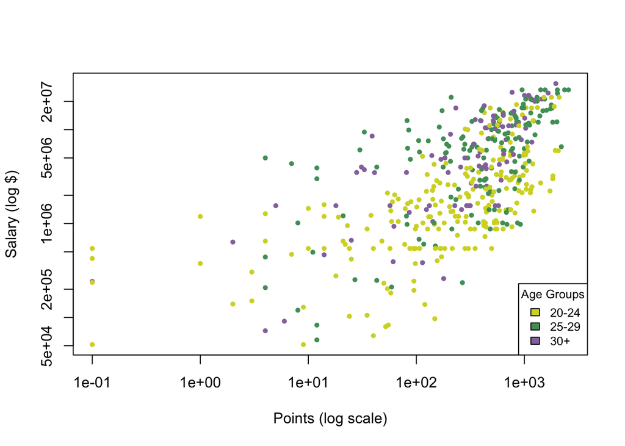

```r
plot(salary ~ points, data = nba, log = "xy", main = "",
xlab = "Points (log scale)", ylab = "Salary (log $)",
col = age_colors, pch = 19, cex = 0.6)
legend("bottomright", fill = palette1, legend = levels(age2),
title = "Age Groups", cex = 0.8)
```